# Выживаемость и посещение форума

## 1. Об отчете

### Исследовательские вопросы

1. Как тип курса влияет на выживаемость студентов?

## Содержание отчета

1. Связь между выживаемостью на курсе и средним посещением форума на курсе

### Описание баз данных

- **students** - длинная база данных, с данными на уровне студентов
- **courses** - короткая база данных, с данными на уровне курсов

### Описание переменных

- **Тип задания** - бинарные переменные; сообщают есть ли такой тип задания на курсе;
  - *is_prog* - есть ли задание по программированию;
  - *is_math* - есть ли задание по математике;
  - *is_peer* - есть ли пир-ревью;
- **Метрики форума**
  - *student_vis_mean* - среднее посещение форума студентами на курсе;
  - *ans_learner* - абсолютное количество ответов студентов на курсе;
  - *q_learner* - абсолютное количество вопросов студентов на курсе;
  - *ans_learner_n* - количество ответов студентов на курсе / количество студентов на курсе;
  - *q_learner_n* - количество вопросов студентов на курсе / количество студентов на курсе;
- **Метрика выживаемости**
  - *passing_rate* - прошедшие курс / записавшиеся на курс

### Как создавались бинарные переменные типов заданий

- К сожалению, не всегда удается автоматически определить какие на курсе задания, а потому приходится использовать разнообразные признаки для их кодирования.
- *is_prog*
  - есть ли в таблице course_items.csv задания со словом “programming”;
  - есть ли в таблице assessment_questions.csv вопросы с типом 14 (codeExpression)
- *is_math*
  - есть ли задания в таблице assessment_math_expression_questions.csv;
  - есть ли в таблице peer_assignment_submission_schema_parts.csv слова “math”,“calculate”, “Рассчитайте”
- *is_peer*
  - есть ли в таблице ‘course_items.csv’ задание с типом 104 (peer-review);

## 2. Посещение форума и выживаемость на курсе

### 2.1 Анализ распределения остатков

Распределение переменных модели:

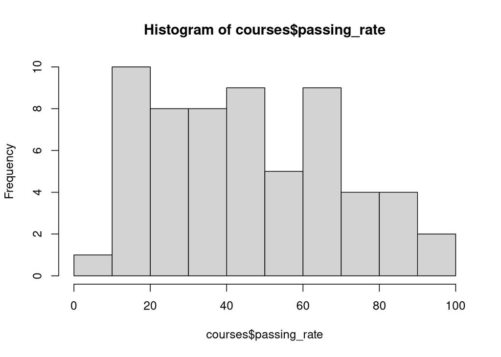

```r
hist(courses$passing_rate)
```

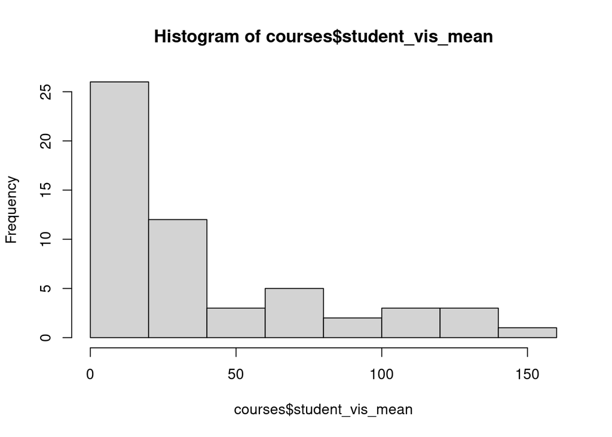

```r
hist(courses$student_vis_mean)
```

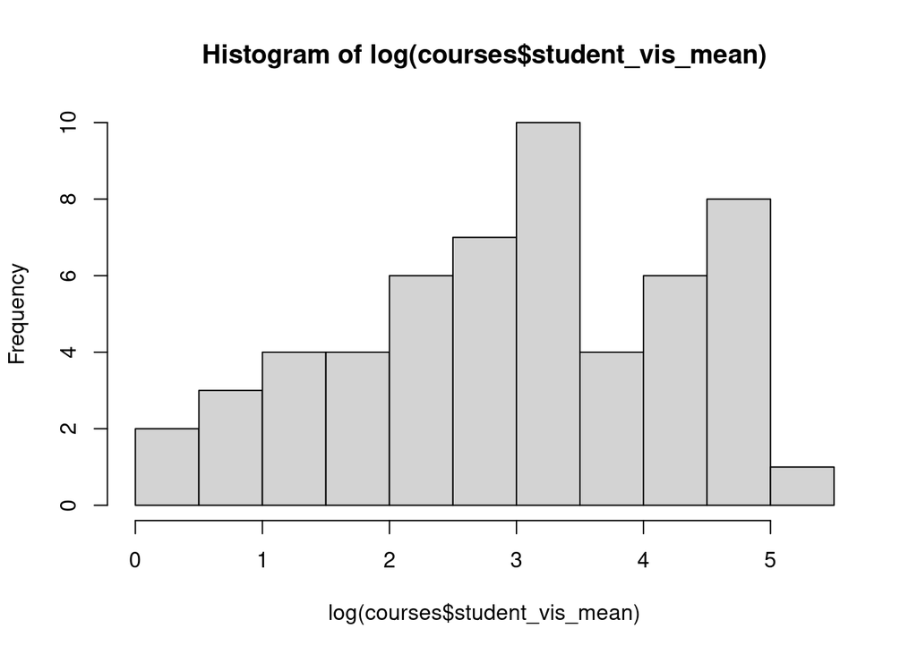

```r
hist(log(courses$student_vis_mean))
```

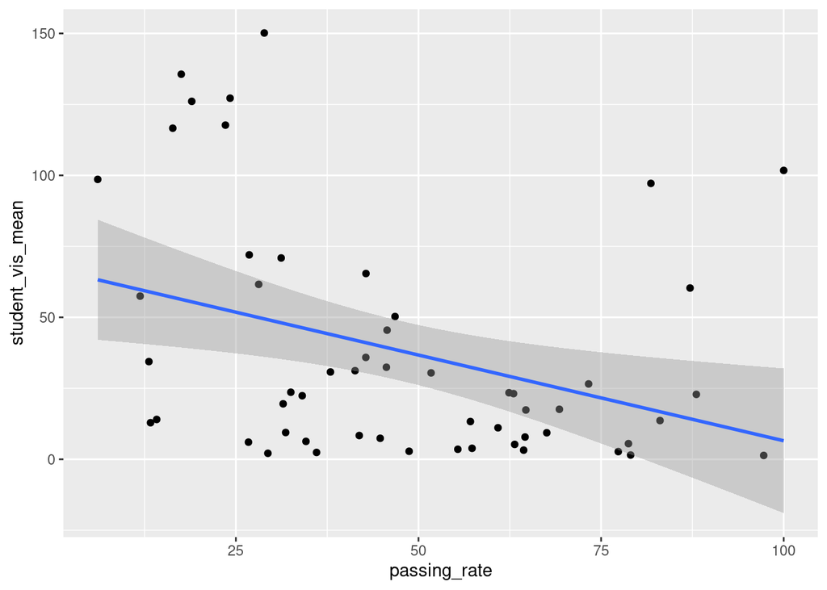

```r
courses %>%
  ggplot(aes(x = passing_rate, y = student_vis_mean)) + geom_point() +  geom_smooth(method = "lm")
```

Распределение остатков зависимой переменной:

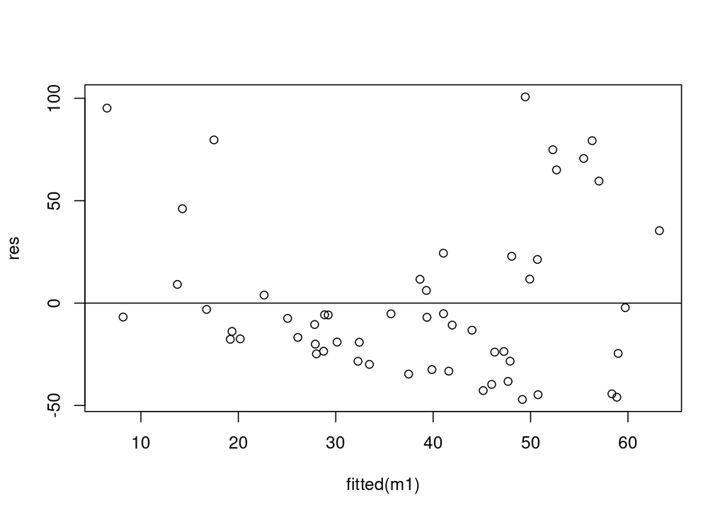

```r
m1 <-  lm((student_vis_mean) ~ passing_rate, courses)
res <- resid(m1)
plot(fitted(m1), res)
abline(0,0)
```

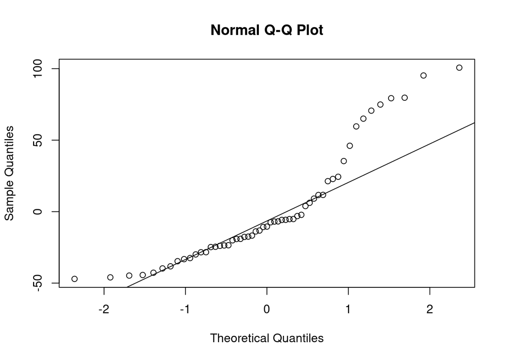

```r
qqnorm(res)
qqline(res)
```

Мы видим, что распределение остатков нельзя назвать нормальным поскольку большая часть значений остатков student_vis_mean скошены. Модель недооценивает значения.

Поэтому мы трансформировали эту переменную с помощью функции log()

### 2.2 Трансформированная регрессия

```r
m1 <-  lm(log(student_vis_mean) ~ passing_rate, courses)
summary(m1)
```

```
##
## Call:
## lm(formula = log(student_vis_mean) ~ passing_rate, data = courses)
##
## Residuals:
##     Min      1Q  Median      3Q     Max
## -2.5715 -1.0068  0.2778  0.8664  2.6871
##
## Coefficients:
##               Estimate Std. Error t value Pr(>|t|)
## (Intercept)   3.889509   0.368696   10.55 1.25e-14 ***
## passing_rate -0.019543   0.006931   -2.82  0.00675 **
## ---
## Signif. codes:  0 '***' 0.001 '**' 0.01 '*' 0.05 '.' 0.1 ' ' 1
##
## Residual standard error: 1.224 on 53 degrees of freedom
##   (5 observations deleted due to missingness)
## Multiple R-squared:  0.1304, Adjusted R-squared:  0.114
## F-statistic: 7.951 on 1 and 53 DF,  p-value: 0.006745
```

```
## Изменение на 1 пункт в выживаемости курса уменьшает на 0.946 пунктов среднее количество посещений форума.
## Чтобы получить данное значение мы нашли разницу между интерсептом и интерсепт + угол наклона, а полученное значение экспоненциировали
## Это изменение значимо с p = 0.007
```

|  | *Dependent variable:* |
| --- | --- |
|  | log(student_vis_mean) |
| Constant | 3.890*** (0.369) |
| passing_rate | -0.020** (0.007) |
| Observations | 55 |
| R<sup>2</sup> | 0.130 |
| Adjusted R<sup>2</sup> | 0.114 |
| F Statistic | 7.951** (df = 1; 53) |
| *Note:* | p<0.05; p<0.01; p<0.001 |

Визуализация

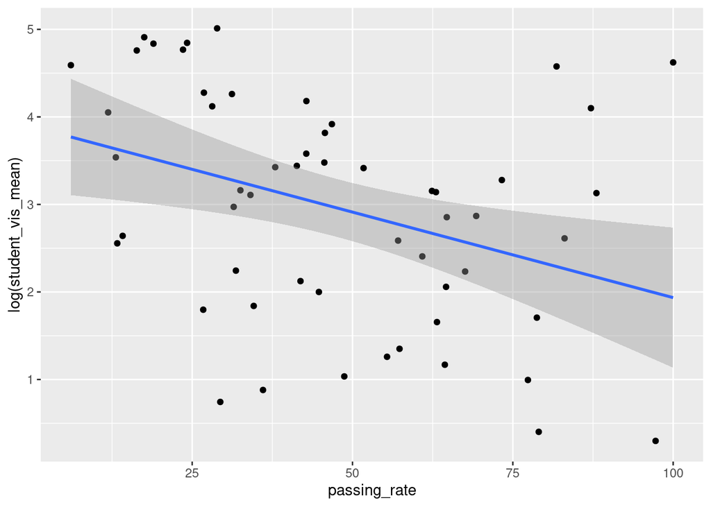

```
## Теперь остатки распределены более равномерно
```

```r
courses %>%
  ggplot(aes(x = passing_rate, y = log(student_vis_mean))) + geom_point() +  geom_smooth(method = "lm")
```

Проверка нормальности распределения

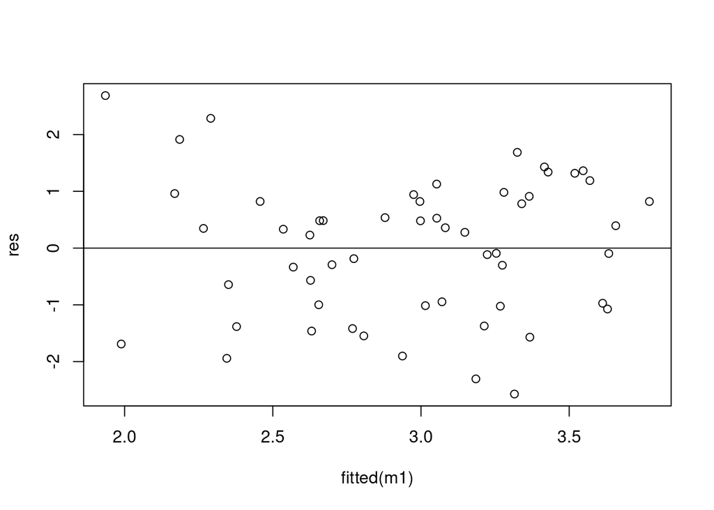

```r
m1 <-  lm(log(student_vis_mean) ~ passing_rate, courses)
res <- resid(m1)
plot(fitted(m1), res)
abline(0,0)
```

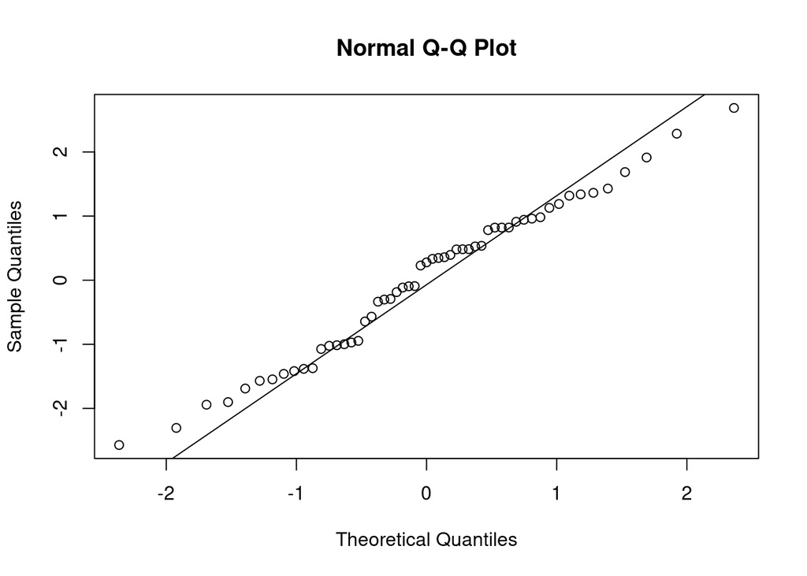

```r
qqnorm(res)
qqline(res)
```

## Выводы

Тактические выводы:

[output not shown]